# hw9

Author

Austin Melendez

Functions from previous homework:

```r
# Set random seed
set.seed(94128)

init_matrix <- function(row,col,start_prop=0.125){
  inf_matrix <- matrix(sample(c(0,1), row*col, replace = TRUE, prob=c(1-start_prop,start_prop)), nrow=row, ncol=col)
}

init_matrix(5,5)
```

```r
dis_plot <- function(row,col,input){
  par(yaxt="n", xaxt="n",ann=FALSE)
  image(1:col,1:row,input)
}
```

## HW 9

**1) Function to create matrix with 1’s in all 4 corners. Default size (20x30)**

```r
create_crnr_matrix <- function(row=20,col=30){
  inf_matrix <- matrix(0, nrow=row, ncol=col)
  inf_matrix[1,1] <- 1
  inf_matrix[1,col] <- 1
  inf_matrix[row,1] <- 1
  inf_matrix[row,col] <- 1
  print(inf_matrix)
}

create_crnr_matrix(5,5)
```

```
     [,1] [,2] [,3] [,4] [,5]
[1,]    1    0    0    0    1
[2,]    0    0    0    0    0
[3,]    0    0    0    0    0
[4,]    0    0    0    0    0
[5,]    1    0    0    0    1
```

**2) Write a function that accepts a probability and a SIR matrix. The function should iterate the model until no more cells are infected and return a list containing the following:**

- number of iterations until no more cells were infected
- probability of infection (same as the argument)
- proportion of cells ultimately infected
- final SIR matrix

```r
infection_step <- function(input, inf_prob = 0.5){
  x <- input

  cc_RL <- init_matrix(nrow(x),ncol(x)-1,inf_prob)
  cc_TB <- init_matrix(nrow(x)-1,ncol(x),inf_prob)
  cc_DIAG <- init_matrix(nrow(x)-1,ncol(x)-1,inf_prob)

  max_col <- ncol(x)
  max_row <- nrow(x)

  xnew <- x

  #ABOVE
  new_inf_above <- ((x[-1, ] == 1) & cc_TB)
  xnew[-max_row, ][new_inf_above] <- 1

  xnew <- x

  #BELOW
  new_inf_below <- ((x[-max_row, ] == 1) & cc_TB)
  xnew[-1, ][new_inf_below] <- 1

  xnew <- x

  #RIGHT
  new_inf_right <- ((x[ ,-max_col] == 1) & cc_RL)
  xnew[, -1][new_inf_right] <- 1

  xnew <- x

  #LEFT
  new_inf_left <- ((x[ ,-1] == 1) & cc_RL)
  xnew[, -max_col][new_inf_left] <- 1

  xnew <- x

  #TOP RIGHT
  new_inf_top_right <- ((x[-1,-max_col] == 1) & cc_DIAG)
  xnew[-max_row, -1][new_inf_top_right] <- 1

  xnew <- x

  #TOP LEFT
  new_inf_top_left <- ((x[-1,-1] == 1) & cc_DIAG)
  xnew[-1, -max_col][new_inf_top_left] <- 1

  xnew <- x

  #BOTTOM LEFT
  new_inf_bot_left <- ((x[-max_row,-1] == 1) & cc_DIAG)
  xnew[-1,-max_col][new_inf_bot_left] <- 1

  xnew <- x

  #BOTTOM RIGHT
  new_inf_bot_right <- ((x[-max_row,-max_col] == 1) & cc_DIAG)
  xnew[-1,-1][new_inf_bot_right] <- 1

  #Set previously infected cells to 2
  xnew[x == 1] <- 2

  #print(xnew)
  return(xnew)
}
```

```r
simulate_sir <- function(row, col, start_inf = 0.125, inf_prob = 0.5){
  x <- matrix(sample(c(0,1), row*col, replace = TRUE, prob=c(1-start_inf,start_inf)), nrow=row, ncol=col)

  step_count <- 0

  while(any(x == 1)){
    x <- infection_step(x, inf_prob)
    #Increment step count for each run
    step_count <- step_count + 1
  }

  num_inf <- sum(x==1) + sum(x==2)
  num_healthy <- sum(x==0)
  num_total <- ncol(x) * nrow(x)

  prop <- num_inf / num_total

  #Print list of results
  results <- list(steps = step_count, start_inf = start_inf, inf_prob = inf_prob, prop = prop, final_matrix = x)

  #print(results$steps)
  #print(results$prop)
  #print(results$final_matrix)
}

simulate_sir(20,30,0.125,0.5)
```

**3) Starting with a 20x30 corner infected matrix, simulate the function at least 1000 times. Summarize all the resulting SIR matrices with one visualization. Which cells are most/least likely to be infected?**

```r
simulation <- function(prob){
  simulations <- replicate(1000, simulate_sir(20,30,prob), simplify = FALSE)

  sx <- 0
  for(s in simulations){
    sx <- sx + s[["final_matrix"]]
  }

  sx <- apply(sx, 2, rev)
  dis_plot(nrow(sx),ncol(sx),t(sx))
}

#simulate(0.5)
```

**4) Simulate using simulate_sir at least 1000 times while varying the probability of infection and create a data frame with one row for every simulation, containing at least the following columns:**

- number of iterations until no more cells were infected
- probability of infection
- proportion of cells ultimately infected

**How do these variables appear to be related? Visualize the relationship between them.**

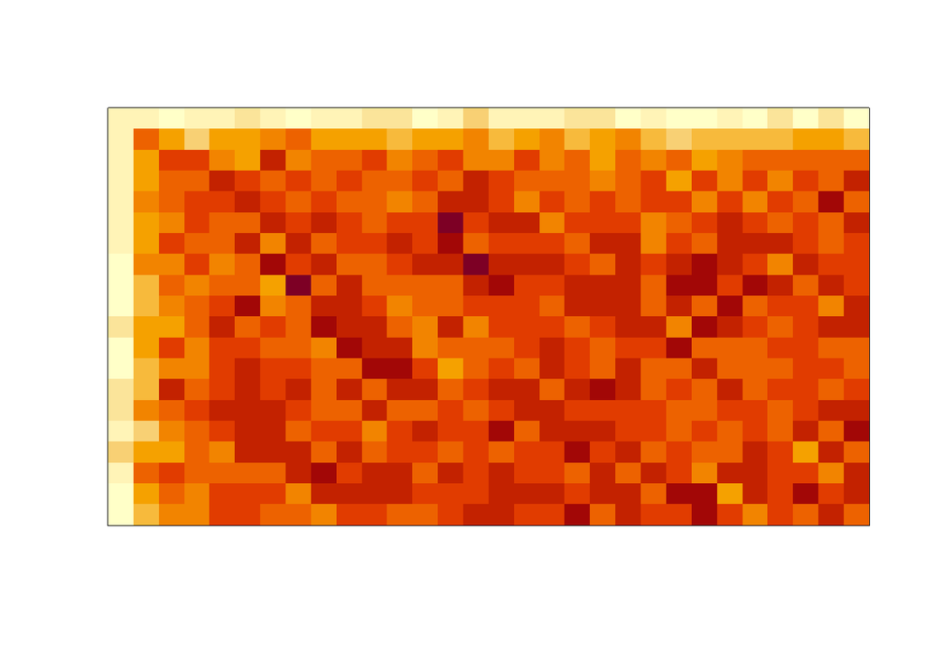

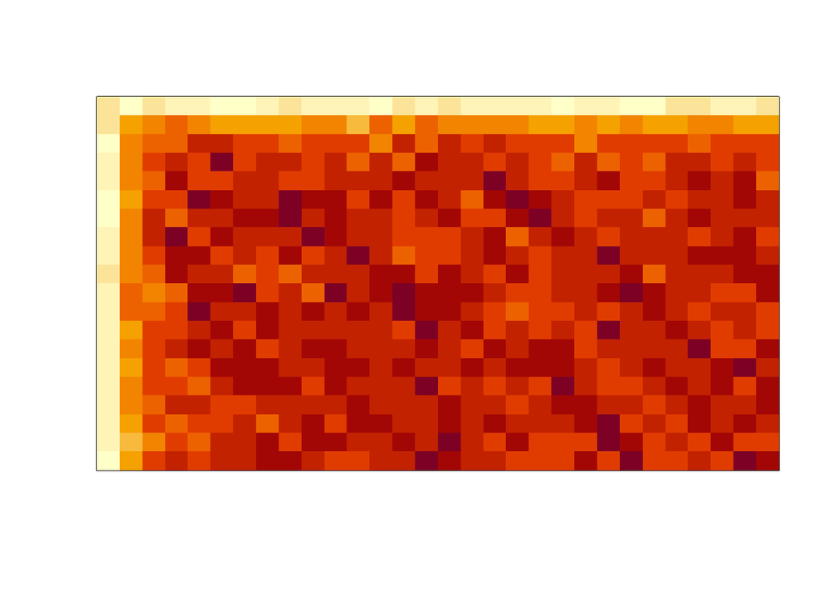

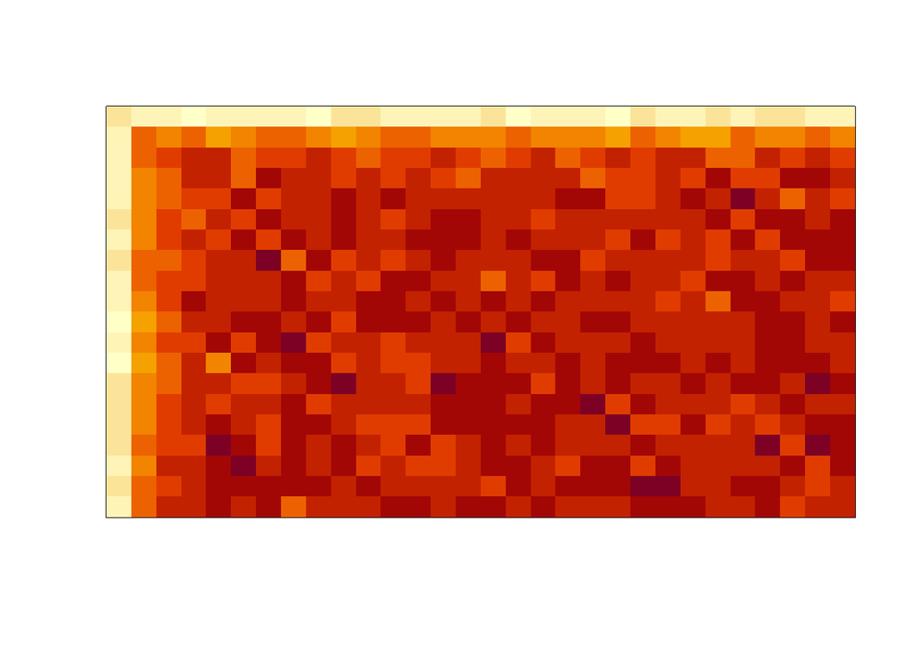

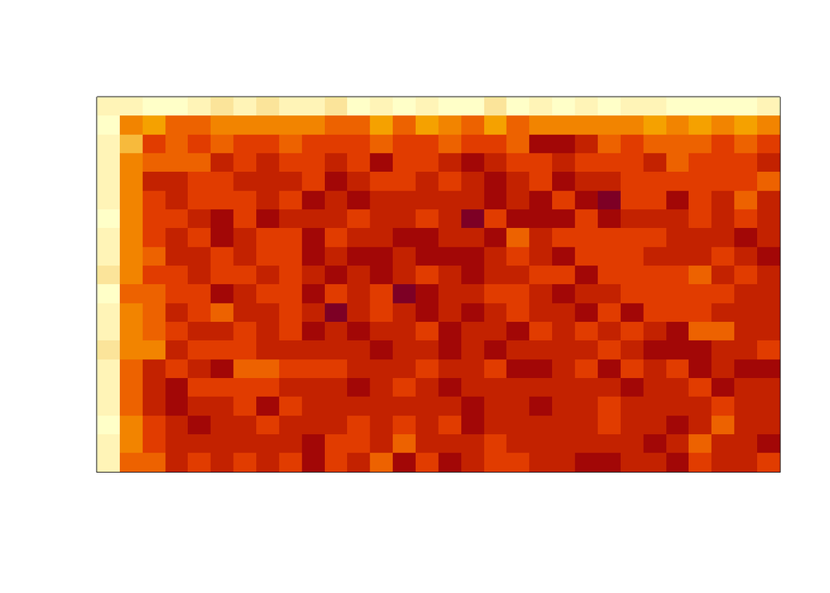

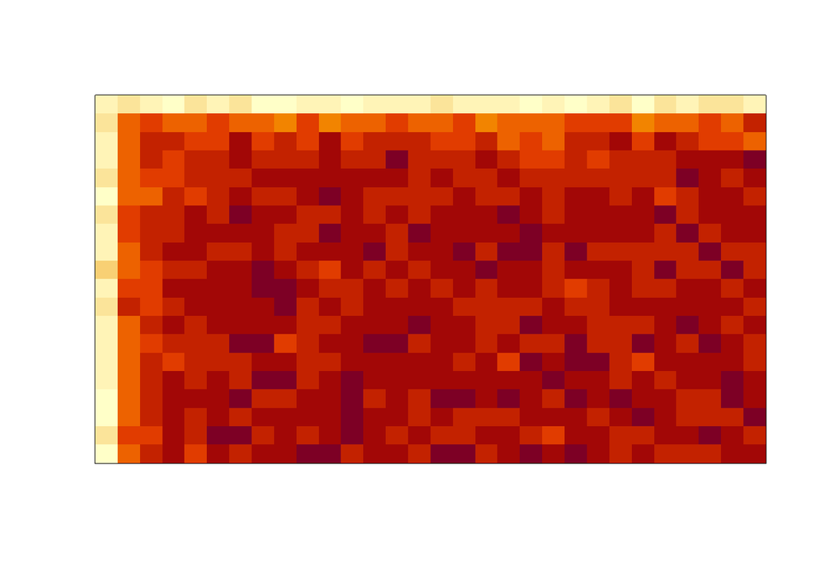

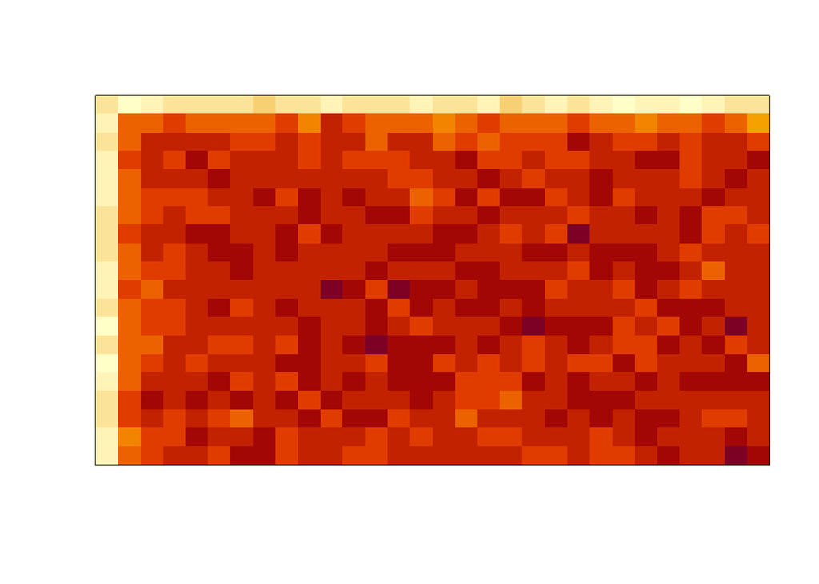

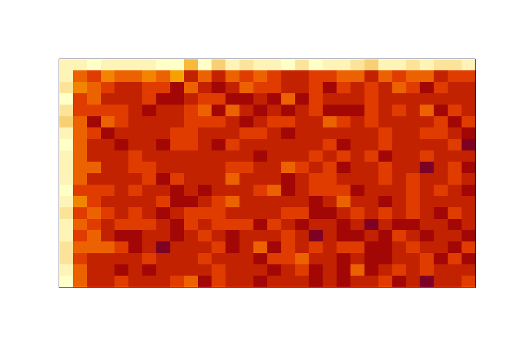

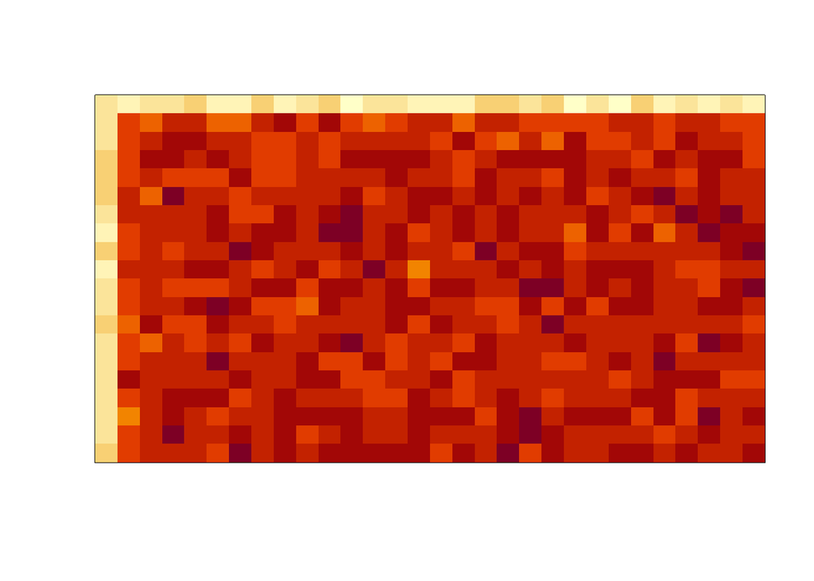

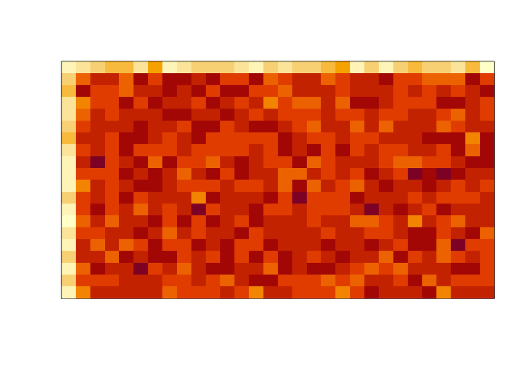

```r
prop_infect <- seq(from = 0.1, to = 0.9, by = 0.1)

results <- lapply(prop_infect, simulation)
```

```r
results2 <- data.frame(
  prob = sapply(results, `[[`, "inf_prob"),
  steps = sapply(results, `[[`, "steps"),
  prop = sapply(results, `[[`, "prop")
)

results2
```

```
data frame with 0 columns and 0 rows
```

```r
library(tidyverse)
#ggplot(results2, aes(x = prob, y = prop)) + geom_point()
```

The data frame is not being created above correctly, this is commented out so I can render the file. My data frame is NULL in every category for some reason.